Copyright Eli Lilly and Company

# The drake R package

Reproducible computation at scale

[figure not shown]

Will Landau

## Why drake?

[figure not shown]

## Data analysis has interconnected steps.

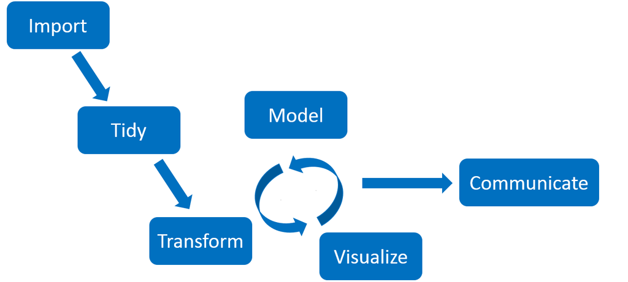

## Each update…

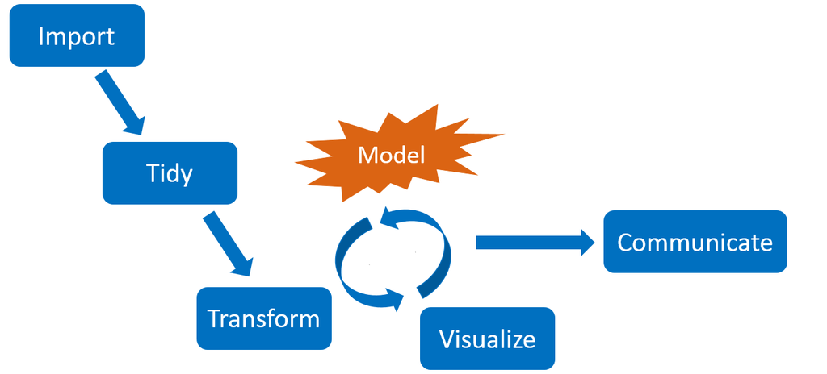

## …can invalidate other work.

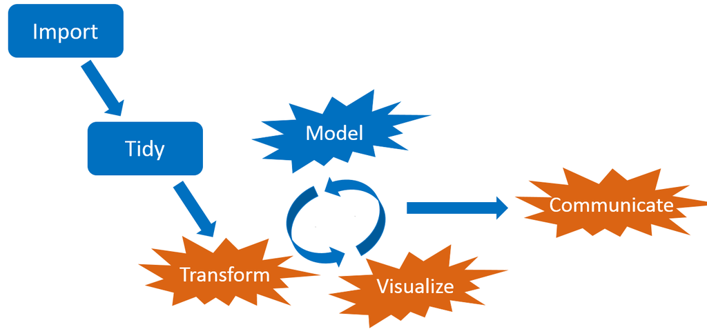

## Do you hunt for all the changes yourself?

- Messy and prone to human error.
- Not reproducible.

[figure not shown]

https://openclipart.org/detail/216179/messy-desk

## Do you rerun everything from scratch?

- Takes too long.
- Too frustrating.

[figure not shown]

https://openclipart.org/detail/275842/sisyphus-overcoming-silhouette

## Pipeline toolkits for large computation

- Lots of tools: github.com/pditommaso/awesome-pipeline.
- Few designed for R.

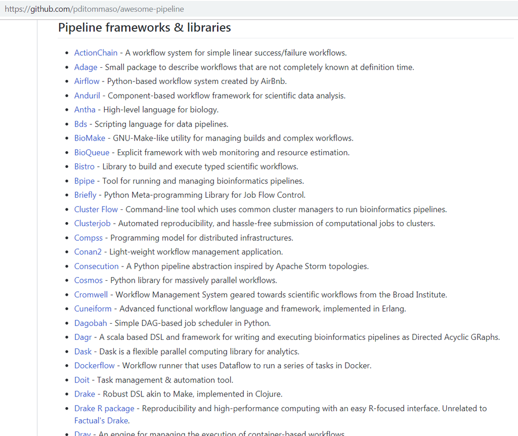

## Small example `drake` project: GDP

- Which quantity is a better predictor of GDP per capita, life expectancy or population?
- [Gapminder data](https://www.gapminder.org/data/): observations on multiple countries from 1952 to 2007.
- Bayesian regeression with [`rstanarm`](https://github.com/stan-dev/rstanarm): straightforward inference and interpretation.
- But Bayesian methods can be **computationally expensive**!

## GDP analysis pipeline

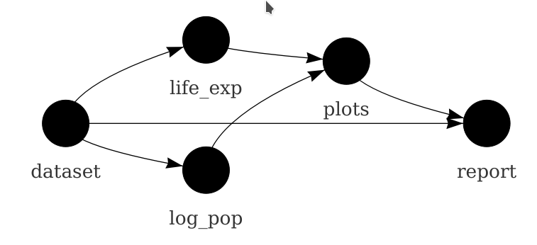

## The drake plan: steps of the workflow.

```r
plan <- drake_plan(
  life_exp = fit_model(covariate = "life_exp", dataset = dataset),
  log_pop = fit_model(covariate = "log_pop", dataset = dataset),
  dataset = prepare_gapminder(gapminder::gapminder),
  plots = gather_plots(life_exp, log_pop),
  report = render(
    knitr_in("report.Rmd"),
    output_file = file_out("report.html")
  )
)
```

## The plan is just a data frame.

```r
plan
```

```
## # A tibble: 5 x 2
##   target   command
##   <chr>    <chr>
## 1 life_exp "fit_model(covariate = \"life_exp\", dataset = dataset)"
## 2 log_pop  "fit_model(covariate = \"log_pop\", dataset = dataset)"
## 3 dataset  prepare_gapminder(gapminder::gapminder)
## 4 plots    gather_plots(life_exp, log_pop)
## 5 report   "render(knitr_in(\"report.Rmd\"), output_file = file_out(\"repo…
```

## Support for the plan

```r
# Load your packages: library(drake), library(gapminder), etc.
source("packages.R")

# Define your functions: prepare_gapminder(), fit_model(), etc.
source("functions.R")
```

## Run your workflow.

```r
make(plan)
## target dataset
## target log_pop
## target life_exp
## target plots
## target report
```

## Output file report.html

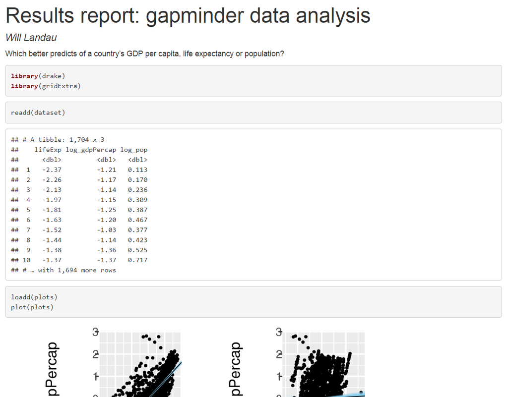

## Get targets from the cache.

```r
readd(dataset)
```

```
## # A tibble: 1,704 x 3
##    life_exp log_gdp_percap log_pop
##       <dbl>          <dbl>   <dbl>
##  1    -2.37          -1.21   0.113
##  2    -2.26          -1.17   0.170
##  3    -2.13          -1.14   0.236
##  4    -1.97          -1.15   0.309
##  5    -1.81          -1.25   0.387
##  6    -1.63          -1.20   0.467
##  7    -1.52          -1.03   0.377
##  8    -1.44          -1.14   0.423
##  9    -1.38          -1.36   0.525
## 10    -1.37          -1.37   0.717
## # … with 1,694 more rows
```

## Find things to improve.

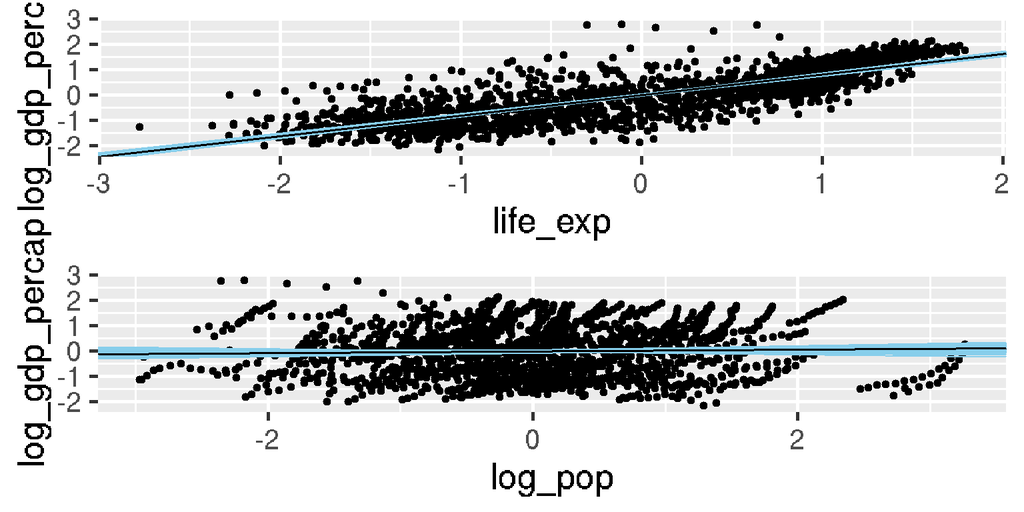

```r
loadd(plots)
plot(plots)
```

## Go back and change a function.

```r
gather_plots
## function (...)
## {
##     grobs <- lapply(list(...), plot_model)
##     arrangeGrob(grobs = grobs)
## }

# Update in functions.R
# and source("functions.R") again.
gather_plots <- function(...) {
  grobs <- lapply(list(...), plot_model)
  arrangeGrob(grobs = grobs, ncol = 2)
}
```

## Which targets need an update?

```r
config <- drake_config(plan)
outdated(config)
```

```
## [1] "plots"  "report"
```

```r
vis_drake_graph(config, targets_only = TRUE)
```

## vis_drake_graph()

[figure not shown]

## Run only the parts that need to change.

```r
make(plan)
## target plots
## target report
```

## Life expectancy has the stronger association.

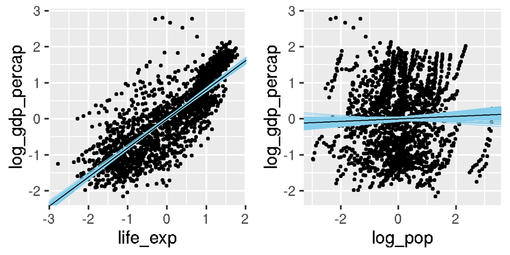

```r
loadd(plots)
plot(plots)
```

## Reproducibilty is about confidence and trust.

- **Tangible evidence** that your results match the code and data at hand:

```r
make(plan)
## All targets are already up to date.

outdated(config)
## character(0)
```

## Scale up to many targets.

- `map_plan()`
- `reduce_plan()`
- `reduce_by()`
- `gather_plan()`
- `gather_by()`
- `evaluate_plan()`
- `expand_plan()`

## Experimental interface

```r
plan <- drake_plan(
  data = target(
    get_data("data_name"),
    transform = cross(data_name = c(oecd, unesco, world_bank))
  ),
  analysis = target(
    fit_large_model(data, "covariate", "priors"),
    transform = cross(
      data,
      covariate = c(log_pop, life_exp, literacy),
      priors = c(normal, t, dirichlet_process)
    )
  ),
  winner = target(
    get_winner(analysis),
    transform = summarize(data, priors)
  )
)
```

## Scale up to many targets.

```r
plan
```

```
## # A tibble: 39 x 2
##    target                         command
##    <chr>                          <chr>
##  1 data_oecd                      "get_data(\"oecd\")"
##  2 data_unesco                    "get_data(\"unesco\")"
##  3 data_world_bank                "get_data(\"world_bank\")"
##  4 analysis_log_pop_normal_data_… "fit_large_model(data_oecd, \"log_pop\",…
##  5 analysis_life_exp_normal_data… "fit_large_model(data_oecd, \"life_exp\"…
##  6 analysis_literacy_normal_data… "fit_large_model(data_oecd, \"literacy\"…
##  7 analysis_log_pop_t_data_oecd   "fit_large_model(data_oecd, \"log_pop\",…
##  8 analysis_life_exp_t_data_oecd  "fit_large_model(data_oecd, \"life_exp\"…
##  9 analysis_literacy_t_data_oecd  "fit_large_model(data_oecd, \"literacy\"…
## 10 analysis_log_pop_dirichlet_pr… "fit_large_model(data_oecd, \"log_pop\",…
## # … with 29 more rows
```

## Scale up to many targets.

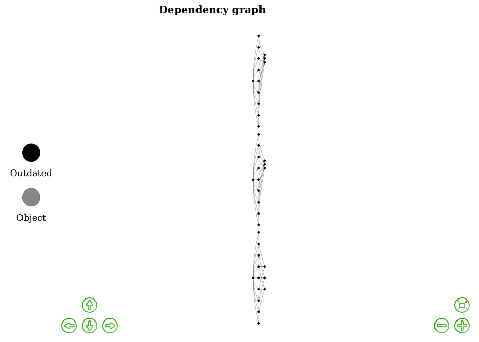

## Scale up to many targets.

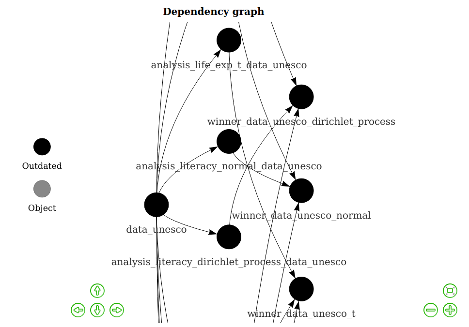

## Persistent parallel workers

```r
# If running locally:
options(clustermq.scheduler = "multicore")

# If on a SLURM cluster (other clusters also supported):
drake_hpc_template_file("slurm_clustermq.tmpl") # Modify by hand.
options(
  clustermq.scheduler = "slurm",
  clustermq.template = "slurm_clustermq.tmpl"
)

# Either way, make() is the same.
make(plan, jobs = 2, parallelism = "clustermq")
```

## Persistent parallel workers

[figure not shown]

## Transient parallel workers

```r
# If running locally:
future::plan(future::multisession)

# If on a SLURM cluster (other clusters also supported):
library(future.batchtools)
drake_hpc_template_file("slurm_batchtools.tmpl") # Modify by hand.
future::plan(batchtools_slurm, template = "slurm_batchtools.tmpl")

# Either way, make() is the same.
make(plan, jobs = 2, parallelism = "future")
```

## Distributed computing: transient workers

[figure not shown]

## Get drake and get help.

```r
install.packages("drake") # CRAN release

library(devtools)
install_github("ropensci/drake") # Development version

library(drake)
drake_example("gapminder") # Download today's code.
```

- [These slides](https://wlandau.github.io/drake-datafest-2019) ([source](https://github.com/wlandau/drake-datafest-2019))
- [Quick reference guide](https://ropensci.github.io/drake/)
- [Technical manual and tutorials](https://ropenscilabs.github.io/drake-manual/)
- [File an issue.](https://github.com/ropensci/drake/issues)
- [Contribute code.](https://github.com/ropensci/drake/pulls)
- [Discuss at rOpenSci.](https://discuss.ropensci.org/)

## Thanks

[figure not shown]

- [Maëlle Salmon](https://github.com/maelle)
- [Ben Marwick](https://github.com/benmarwick)
- [Julia Lowndes](https://github.com/jules32)
- [Peter Slaughter](https://github.com/gothub)
- [Jenny Bryan](https://github.com/jennybc)
- [Rich FitzJohn](https://github.com/richfitz)
- [Stefanie Butland](https://github.com/stefaniebutland)
- [Jarad Niemi](https://github.com/jarad)
- [Kirill Müller](https://github.com/krlmlr)
- [Kendon Bell](https://github.com/kendonB)
- [Alex Axthelm](https://github.com/AlexAxthelm)
- [Jasper Clarkberg](https://github.com/dapperjapper)
- [Henrik Bengtsson](https://github.com/HenrikBengtsson)
- [Eric Nantz](https://github.com/thercast)
- [Ian Watson](https://github.com/IanAWatson)
- [Daniel Falster](https://github.com/dfalster)
- [Chan-Yub Park](https://github.com/mrchypark)
- [Tiernan Martin](https://github.com/tiernanmartin)

## References

- [`drake`](https://github.com/ropensci/drake)
- [rOpenSci](https://ropensci.org)
- [Gapminder](https://www.gapminder.org) and the [`gapminder` package](https://github.com/jennybc/gapminder)
- [List of pipeline toolkits](https://github.com/pditommaso/awesome-pipeline)
- Images (desk, [Sisyphus](https://openclipart.org/detail/275842/sisyphus-overcoming-silhouette)) taken from from openclipart.org under [CC0 1.0](https://creativecommons.org/publicdomain/zero/1.0/), [unlimited commercial use](https://openclipart.org/unlimited-commercial-use-clipart).
- The embedded parallel computing animations were created using [PowToon](https://www.powtoon.com) and are used only as explicitly permitted in the [Terms and Conditions of Use](https://www.powtoon.com/terms-and-conditions/). The maintainers of and contributors to `drake` make no copyright claim to any of the constituent graphicical elements that comprise the animations.